# PRÀCTICA 1

Martina Carreño, Laura Jordan i Berta Serrabasa

2025-03-03

```
seq<-MKYLNCFISTGLAAFFLVNSTSVLAADCSSDLTSGISTKRIYYVAPNGSSSNNGNSFNSP…
```

## 1. Sobre la Proteïna

- **Nom del gen corresponent:** Pectate lyase L
- **Codi Uniprot:** P0C1A6
- **Classificació:** EC:4.2.2.2
- **Funció:** Presenta activitat endo-cleaving sobre polygalacturonate o pectina parcialment metilada.
- **Codi PDB:** 1RU4_A
- **Funció:**La Pectate lyase L és un enzim que degrada la pectina, un component estructural de la paret cel·lular vegetal. Concretament, trenca els enllaços èster en els àcids poli-galacturònics mitjançant un mecanisme de β-eliminació, facilitant així la descomposició dels teixits vegetals.

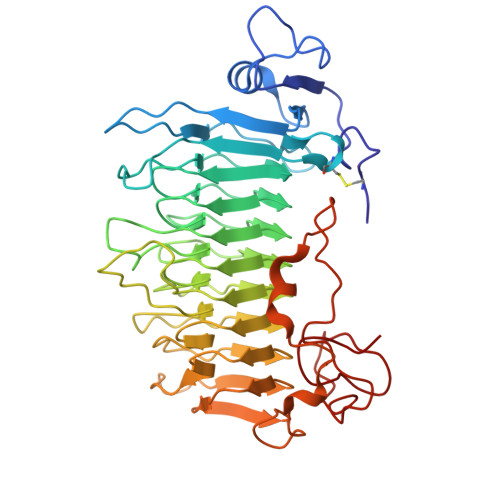

Fig.1 Pectate lyase L

## 2. Treball amb Chimera X

### Estructures secundàries

- **Hèlix alfa (4 identificades)**
  - Tipus 1: Hèlix alfa clàssica amb ponts d’hidrogen intracatenaris cada 4 residus (entre el grup carbonil del residu i i l’N-H del residu i+4).
  - Tipus 5: Hèlix més estirada amb ponts cada 5 residus.
  - Interaccions:
    - Ponts d’hidrogen: Estabilitzen l’estructura i mantenen l’hèlix compacta.
    - Interaccions hidrofòbiques:Entre cadenes laterals apolars orientades cap al centre de l’hèlix.
    - Interaccions electrostàtiques:Entre residus carregats, especialment a les vores de l’hèlix.
- **Fulles beta (32 identificades)**
  - Tipus 0: Fulles beta paral·leles, on els ponts d’hidrogen són gairebé simètrics, amb les cadenes laterals alternant cap amunt i cap avall.
  - Tipus 1: Fulles beta antiparal·leles amb ponts d’hidrogen més forts perquè s’alineen directament (lineals).
  - Interaccions:
    - Interaccions hidrofòbiques:Entre residus apolars situats a la mateixa cara de la fulla.
    - Ponts de sal:Si hi ha residus carregats a les vores, poden establir interaccions iònics amb residus propers.
- **Loops (13 identificats)**  
  Els loops són estructures flexibles que connecten les hèlix i les fulles beta. Dins d’aquests:
  - Hem detectat 3 ponts d’hidrogen interns, sovint entre el carbonil i l’N-H d’aminoàcids propers, tot i que menys estructurats que en les hèlix o fulles.
  - Els loops també poden interaccionar amb altres estructures secundàries, estabilitzant l’estructura global de la proteïna.

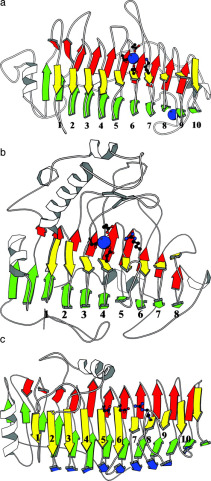

Fig.2 L’arquitectura de tres dominis β-hèlix paral·lels

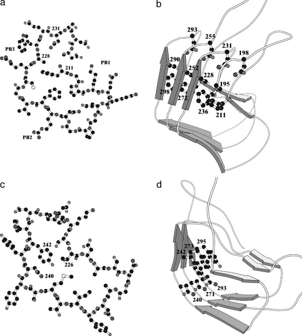

Fig.3 Piles de cadenes laterals diferents dins del domini de l’hèlix β paral·lel de Pel9A.

### Motius d’estructura supersecundària

Els motius d’estructura supersecundaria que trobem son α-hèlix, fulles β i llaços. En aquesta estructura trobem 10 ponts d’hidrogen que estabilitzen les estructures principalment entre els grups NH i C=O. També trobem forces de van de Waals ( atracció entre resiuds polars que estabilitzen el nicli de la proteïna) , interaccions hidrofòbiques i ponts salins (interaccions entre Adp i Arg que son aa carregats).

### Estructura terciària i quaternària

- **Plegament:** Hèlix β paral·lela
- **Classificació SCOP:**
  - Classe: All beta proteins
  - Plegament: Pectin lyase-like
  - Superfamília: Pectin lyase-like
  - Família: Pectate lyase
- **Estructura quaternària:** Generalment monòmers, però pot formar oligòmers

## 3. Funció de la Proteïna

- **Lloc de coordinació del calci**:Un ió de calci de gran afinitat està coordinat per diversos residus aspartats, principalment Asp-209, Asp-233 i Asp-237 (amb un paper similar al descrit en estructures comparables, com en PelC). Aquest calci no sols estabilitza la configuració de l’enzyme sinó que també interacciona amb el substrat, ajudant a posicionar el grup carboxilat de la residu en subsite −1.

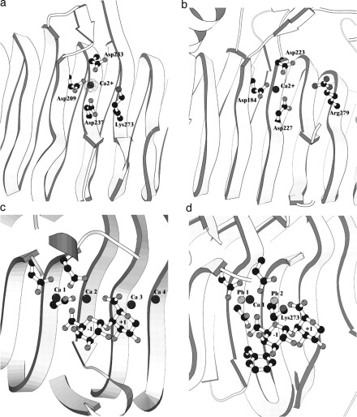

Fig.4 Els llocs d’unió al calci de Pel9A i Pel1A.

- **Residu catalític:**Lys-273 és el candidat principal per actuar com a base catalítica, encarregat d’extreure el protó del C5 del substrat durant el mecanisme d’eliminació anti-E1cb. La importància d’aquest residu es recolza en l’estudi de mutagènia, ja que la seva substitució per alanina o per arginina redueix dràsticament l’activitat enzimàtica.
- **Altres residus rellevants**: La xapa de substrat també incorpora altres residus carboxilats, com Asp-299 i Glu-180, que podrien participar en interaccions amb els grups carboxilats del substrat, possiblement mitjançant ponts de calci o interaccions electrostàtiques i d’hidrogen, contribuint així a la correcta orientació i estabilització del complex enzim-substrat.
- **Presència de substrat o inhibidor**:Pel que fa a la presència de substrat o inhibidor en l’estructura resolta, tot i haver-se intentat obtenir complexos amb substrat i calci (o utilitzar ions plom per inferir la presència de llocs addicionals de calci), els cristalls de Pel9A no mostren un lligand (substrat o inhibidor) lligat de forma directa. No obstant això, l’anàlisi amb ions plom suggereix l’existència d’un segon lloc de calci, que en els complexos de Michaelis (com en la comparació amb PelC) estaria implicat en pontar el substrat amb l’enzyme.
- **Interaccions dins del centre actiu**:
  - El calci primari està fortament coordinat pels grups carboxilats d’Asp-209, Asp-233 i Asp-237, establint ponts de coordinació que ajuden a mantenir la geometria adequada per a la reacció i, indirectament, en fixar el substrat.
  - Lys-273, situat a prop d’aquest lloc, actua com a base catalítica, i la seva posició relativa al calci facilita l’absenció del protó del C5 del substrat, iniciant el mecanisme d’eliminació.
  - Els residus Asp-299 i Glu-180, situats a la xapa del substrat, poden formar interaccions electrostàtiques i de ponts d’hidrogen amb els grups carboxilats i hidroxil del substrat, contribuint a l’estabilització del complex enzim-substrat.

En resum, el centre actiu de Pel9A està definit pel lloc de coordinació del calci (Asp-209, Asp-233, Asp-237), amb Lys-273 com a residu clau per a la catalisi, i complementat per altres residus (com Asp-299 i Glu-180) que potencialment ajuden a fixar el substrat. L’estructura resolta no conté un substrat o inhibidor lligat directament, però els estudis amb ions plom indiquen la presència d’un segon lloc de calci que seria rellevant en la formació del complex catalític.

### Funció de la proteïna

La pectat liasa L és un enzim que degrada la pectina, un component estructural important de la paret cel·lular de les plantes. Catalitza la clivació de pectats (polímers d’àcid galacturònic) mitjançant un mecanisme de β-eliminació, alliberant oligosacàrids insaturats. A diferència d’altres enzims com les poligalacturonases, actua específicament sobre pectats desmetilats (pectat i àcid poligalacturònic). La seva activitat afebleix la paret cel·lular vegetal, facilitant processos com la maceració i la degradació dels teixits vegetals.

A més de la seva funció general en la degradació de la pectina, la pectat liasa L pot presentar característiques específiques segons l’organisme en què es troba. Aquest enzim catalitza la β-eliminació, un procés que genera un doble enllaç en els productes finals, modificant-ne la reactivitat química i la solubilitat. Sovint, requereix ions divalents com Ca²⁺ per estabilitzar la seva estructura i activar el substrat. A diferència d’altres pectat liases, la seva activitat pot variar segons el grau d’acetilació i esterificació de la pectina.

A nivell biològic, la pectat liasa L és una eina clau per a bacteris i fongs fitopatògens com Erwinia, Pectobacterium i Aspergillus, que la utilitzen per degradar la paret cel·lular vegetal i facilitar la infecció. També pot estar present en microorganismes simbionts d’insectes herbívors, ajudant en la digestió dels teixits vegetals.

En l’àmbit biotecnològic, la pectat liasa L té múltiples aplicacions. En la indústria alimentària, s’empra per millorar la clarificació de sucs, optimitzar l’extracció d’olis i pigments, i facilitar la fermentació de productes vegetals. En el sector tèxtil i paperer, es fa servir per al processament de fibres vegetals riques en pectina. Finalment, en enginyeria genètica, es poden modificar aquestes enzims per obtenir una activitat optimitzada en diferents condicions de pH i temperatura, ampliant-ne les aplicacions en biotecnologia.

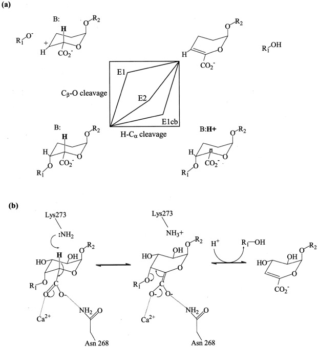

Fig. 5 a) Diagrama d’O’Ferrall per a l’eliminació β d’àcids urònics configurats amb galacto (33, 34, 38) on l’ordre d’enllaç per a la divisió H-Cα es representa al llarg de l’eix x i la divisió de l’enllaç Cβ–O es representa al llarg de l’eix y. b)mecanisme de reacció putatiu E1cb/E2 asíncron per als enzims Pel9A en què la lisina abstraeix el protó, donant lloc a l’eliminació del grup abandonant.

### Relació seqüència-estructura-funció

L’estructura de la Pectate lyase L està directament relacionada amb la seva funció catalítica en la degradació de la pectina.

- **Domini estructural i estabilitat**: L’enzim presenta una estructura de làmines β paral·leles, característica de moltes hidrolases i liases.A més, les hèlix α (tipus 1 i 5) i els loops ajuden a estabilitzar l’estructura global i poden estar implicats en la unió al substrat.Les interaccions hidrofòbiques, ponts d’hidrogen i interaccions electrostàtiques contribueixen a l’estabilitat de l’estructura i a l’orientació correcta del centre actiu.
- **Centre actiu i mecanisme catalític**:L’enzim actua per un mecanisme de β-eliminació, trencant els enllaços glicosídics de l’àcid poligalacturònic. A més, l’ió Ca²⁺, coordinat per Asp-209, Asp-233 i Asp-237, és essencial per estabilitzar l’enzim i per posicionar el substrat correctament. La Lys-273 actua com a base catalítica, iniciant la reacció enzimàtica, i l’Asp-299 i el Glu-180 interaccionen amb els grups carboxilats del substrat, estabilitzant la unió i facilitant la catàlisi.
- **Relació amb la seqüència**: La presència de residus àcids (Asp, Glu) en el centre actiu facilita la interacció amb el substrat carregat negativament. Les regions conservades en altres pectat liases indiquen la importància funcional d’aquests dominis estructurals. A més, algunes variants de la proteïna poden modificar l’afinitat pel substrat o l’eficiència catalítica, afectant la seva activitat enzimàtica.
- **Variants i implicacions funcionals**:Les mutacions en Lys-273 redueixen dràsticament l’activitat enzimàtica, demostrant el seu paper crític en la catàlisi.També, les modificacions en la coordinació del calci poden alterar la funció de l’enzim, ja que aquest element és clau per a la seva activitat.A més, algunes variants poden adaptar-se a diferents condicions de pH i temperatura, fet que pot tenir aplicacions en biotecnologia.

En resum, la seqüència determina l’estructura, i aquesta estructura defineix la funció de l’enzim. Els elements clau inclouen les làmines β paral·leles, els residus catalítics i la coordinació del calci, tots fonamentals per a la degradació eficient de la pectina.

### Elements estructurals que participen en la funció

- **Fulles β i hèlix α**: L’enzim té una estructura dominada per fulles β paral·leles, que formen el nucli estructural de la proteïna. Aquestes fulles estabilitzen la conformació necessària per al centre actiu.
- **Lloc de coordinació del calci**: Els residus Asp-209, Asp-233 i Asp-237 són essencials per estabilitzar el ió de Ca²⁺, que alhora facilita la interacció amb el substrat.
- **Base catalítica**: Lys-273 és clau per a l’eliminació β, actuant com a base que desprotona el substrat.
- **Interaccions secundàries**: Residus com Asp-299 i Glu-180 poden estabilitzar el substrat mitjançant ponts d’hidrogen i interaccions electrostàtiques.

### Conseqüències moleculars

- Pèrdua de funció: Si el centre actiu es veu afectat per mutacions que impedeixen la coordinació del calci o la desprotonació del substrat, l’enzim deixa de ser funcional.
- Canvis en l’eficiència catalítica: Algunes variants podrien modificar la velocitat de reacció, fent l’enzim més o menys eficient segons les condicions ambientals.
- Efectes en aplicacions biotecnològiques: Variants estabilitzades podrien ser útils en processos industrials, mentre que mutacions que redueixen l’activitat podrien ser beneficioses en aplicacions on es vulgui controlar la degradació de pectina.